# DATA 602 Term Project

…

# Analysis 1

## Introduction

The study of astrophysics seeks to better understand and explain the forces and relationships that govern objects and phenomena across our universe. Through the application of chemistry and physics to stellar observations many innovative insights have been achieved; for example, the temperatures of distant stars have been accurately measured by analyzing the ratios of emitted wavelengths. Two particularly important insights involved the shifts in the emissions spectrums of astronomical objects and the angle between objects and Earth, which have allowed the measurements of the speed and distance of far away objects, respectively. These measurements of speed and distance have led to perhaps the most well-known astrophysical conclusion of all, that the universe is expanding.

This concept was originally put forward by Edwin Hubble in 1929 (NASA, n.d.). Hubble’s conclusion received much publicity and ran contrary to many commonly held opinions of the time. Despite being commonly cited as one of the most revolutionary discoveries in the history of astrophysics, the underlying evidence is scarcely known. The assertion that the universe is expanding rested on the observations that the further an astronomical object was from earth, the faster it appeared to be moving. Hubble realized that such an observation was best explained by a theory wherein empty space was increasing in size.

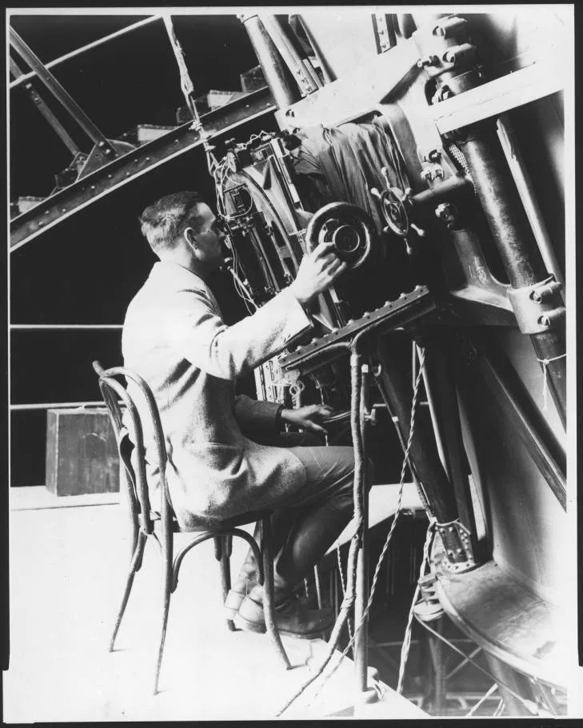

Edwin Hubble Seated at the Mount Wilson Observatory Edwin P. Hubble Papers, Huntington Library, San Marino, California (NASA, n.d.)

Despite the wide acceptance of the expanding universe theory, it can be a difficult concept to grasp. In this project, we aim to examine publicly available data pertaining to the speeds and distances of astronomical objects to better understand the conditions and evidence of the expanding universe theory. Our model of the universe’s expansion is illustrated below. In this model, the universe is portrayed as a two dimensional grid that expands over a period of time. As the grid doubles in size, the distances between both the red dots and the blue dots correspondingly double as well. Interestingly, the blue dots must have travelled twice as fast (relative to each other) as the red dots, as the distance between the blue dots increased by twice as much as the red dots over the same time period.

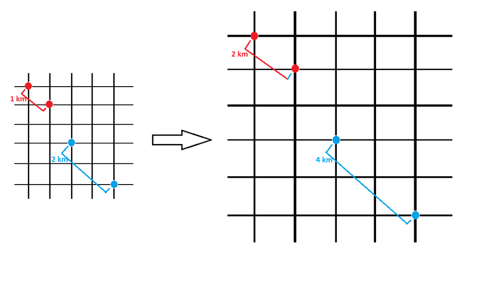

Simplified Uninverse Expansion Model

This model of the universe expansion would suggest a linear relationship between the distance an object is from an observer and its speed. As such, we set out to attempt to test the validity of this model by creating a linear function representing this relationship.

## Description of data source

To create this model, we first obtained data from the Gaia space observatory. The Gaia space observatory was launched by the European Space Agency (ESA) in 2013 (Gaia Collaboration, 2016). The data used in this project is from the third data release, completed in 2023. Initial processing and validation of the data was completed by the Gaia space observatory, the Gaia Data Processing and Analytics Consortium (GPDAC). GPDAC encourages public use of the data, and maintains no reservations or holds. The dataset is licensed under the DbCL v1.0 agreement, which allows users to share, modify, and use the contents as long as they source the dataset (Open Data Commons, n.d.).

The space observatory is in a fixed orbit near earth, and continuously rotates about an axis, such that, over a period of 6 hours, it will sample across all visible objects perpendicular to its axis (ESA, 2023). The axis of rotation additionally shifts slowly over time to provide full coverage of the satellites surroundings (ESA, 2023). Given the methodical nature of the observatories sampling, the resulting data can not strictly be considered random. However, the observations in the dataset were sampled throughout the possible fields of view, and can be considered representative of the satellites surroundings. Given that the primary purpose of random sampling is to ensure the accurate representation of a population by a sample, we decided to cautiously proceed with tests that require assumptions of randomness. Similarly, the independence of samples are also influenced by the sampling procedure. In this case, it is unlikely that any of the observed astronomical objects are interdependent; even if the samples are observed in the same field of view, they are almost certainly separated by a vast distance that negates gravitational effects or other forces that act over long distances.

## Linear Model

### Data Visualization

As the dataset was large ($n$ > 600,000), we first took a random sample of 100,000 observations to increase computational speed. We then created a scatter plot of the speeds of astronomical objects as a function of their distance away from Earth (Figure 2). The plot did vaguely show that farther astronomical objects tended to be moving faster, but a high density of objects that were relatively near Earth and moving at a large range of speeds clouded any clear relationship.

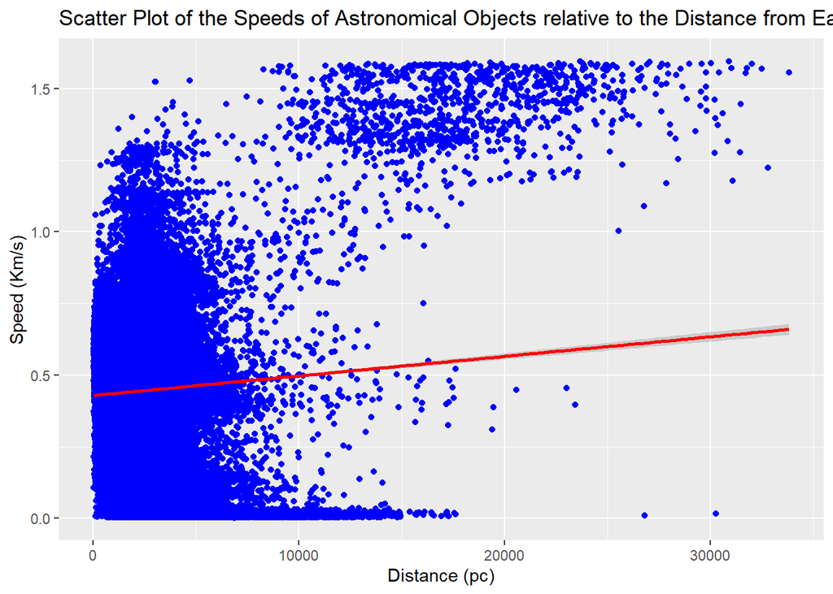

```r
df <- read.csv("C:/Users/hurdg/OneDrive/Documents/MDSA/DATA 602/Data 602 - Project/dataGaia.csv")

#Remove missing values from speed (z.flame) and distance (Dist) columns
df2 = df[is.na(df$z.Flame)==FALSE & is.na(df$Dist)==FALSE,]


#Random sample for computational speed
set.seed(4321)
sampled = df2[sample(1:nrow(df2), 100000, replace = FALSE),]

#Select and rename speed and distance columns in new dataframe
data = data.frame("distance" = sampled$Dist, "speed" = sampled$z.Flame)

#Visualize data
library(ggplot2)

ggplot(data, aes(x = distance, y = speed)) + geom_point(col = "blue") + geom_smooth(method = "lm", col = "red")+
  xlab("Distance (pc)") + ylab("Speed (Km/s)") + ggtitle("Scatter Plot of the Speeds of Astronomical Objects relative to the Distance from Earth")
```

Despite the concerns brought about by the scatter plot, we further tested the conditions required of a linear relationship. To test the condition of normality, we calculated the standardized residuals of the speeds and created a normal probability plot. Additionally, we assessed the homoscedasticity of the linear model by plotting the standardized residuals relative to the observed distance values.

```r
library(gridExtra)
library(ggformula)
#Linear model
expansion.model = lm(speed ~ distance, data = data)
expansion.model$coefficients
```

```
##    (Intercept)       distance
## 0.429202198434 0.000006813431
```

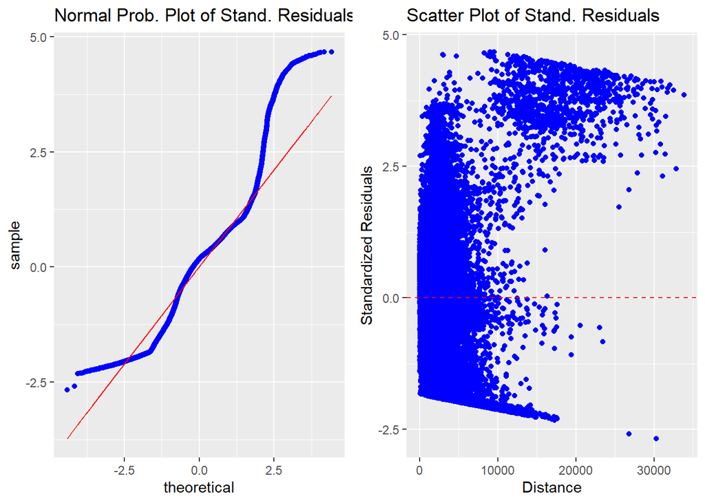

```r
#New dataframe of diagnostic values
diagnosticdf = data.frame("speed" = data$speed, "distance" = data$distance, predicted.speed = expansion.model$fitted.values,
                          residuals = expansion.model$residuals,
                          "standardized.residuals" = expansion.model$residuals/(summary(expansion.model)$sigma * sqrt(1-hatvalues(expansion.model))))

#Normal plot of standardized y-axis residuals to test normality
normal_test = ggplot(diagnosticdf, aes(sample = standardized.residuals)) + stat_qq(col = "blue") + stat_qqline(col = "red") + ggtitle("Normal Prob. Plot of Stand. Residuals")

#standardized residuals relative to x-values to test homoscedasity
const.var_test = ggplot(diagnosticdf, aes(x = distance, y = standardized.residuals)) + geom_point(col = "blue", position = "jitter") +
  xlab("Distance") + ylab("Standardized Residuals") + ggtitle("Scatter Plot of Stand. Residuals") +
  geom_hline(yintercept = 0, color = "red", linetype = "dashed")


grid.arrange(normal_test, const.var_test, ncol=2)
```

The standardized residuals roughly followed a normal distribution, but somewhat deviated from the theoretical values, particularly near both extremes. From this alone, the appropriateness of a linear model was questionable. Furthermore, the standardized residuals of the speeds of astronomical objects were not evenly distributed relative to the distance away from Earth. This signifies that the variance in speeds is not constant; consequently, the use of a linear model to represent the relationship between speed and distance is definitively not appropriate.

## Two Sample Model

Without the option of a linear model, we opted to shift our study question and test the relationship in other ways. By reclassifying the distances of astronomical objects as categorical variables, a comparison of the mean speeds of each distance category would be possible.

### Categorizing the Distance Variable

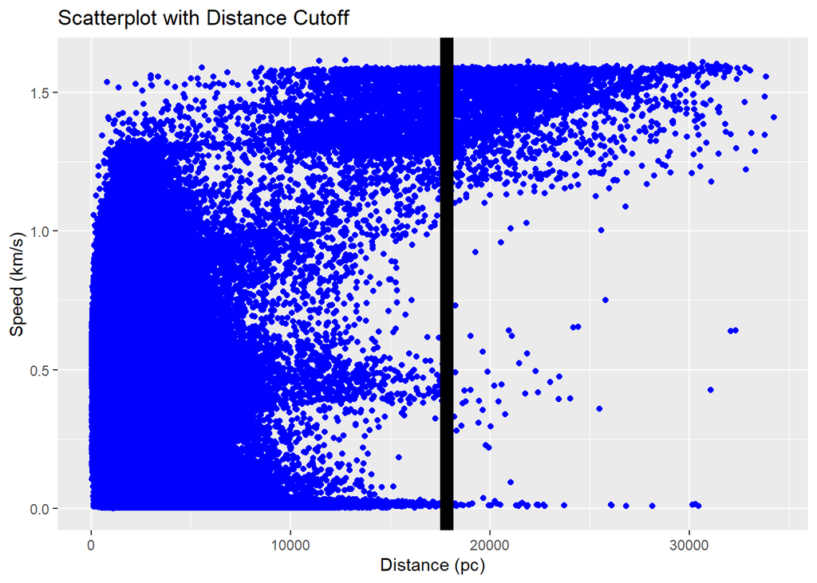

```r
cutoff = max(df$Dist)/2

df2$distance_class = ifelse(df2$Dist <= cutoff, "Near", "Far")

#Select and rename speed and distance columns in new dataframe
data = data.frame("distance_class" = df2$distance_class, "speed" = df2$z.Flame)

#Scatterplot of Distance Cutoff
ggplot(data = df2, aes(x = Dist , y = z.Flame)) +
  geom_point(col = "blue") +
  geom_vline(xintercept = cutoff, size = 4)+
  xlab("Distance (pc)") + ylab("Speed (km/s)") + ggtitle("Scatterplot with Distance Cutoff")
```

As can be seen in the scatterplot, the astronomical objects appear to be unevenly distributed relative to the cutoff value. In fact, the *Near* group contains 594865 astronomical objects, while the *Far* group is only composed of 2693. One possible explanation is that there are simply less stars farther away. However, we suspect that it is more likely an observation bias; as light diffuses as it radiates outward, we suspect that the brightness of a star is inversely related to its visibility from far distances. To account for this possibility, we specified our populations in question to only consist of *observable* astronomical objects.

Additionally, the drastic inequality in sample size did cause concern regarding its impact on the two-sample test. However, we determined that the principle effect of unequal sample sizes would be greater variance in the group with the smaller sample size. In our case, this was the far group. Greater variance in the far group is likely to manifest as an increased likelihood of a type II error. This principle is visualized in the below figure. The increased variance is represented by a wider and shorter distribution in the lower instance of the “B” sample. This change creates more opportunities for a conclusion of no significant difference. when in fact the population means are different, as represented by the area in red.

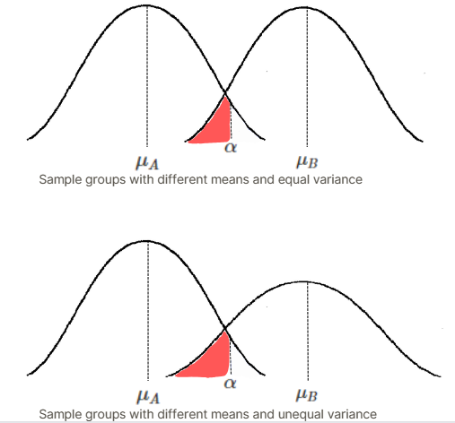

Effect of Unequal Sample Sizes on Type II Error

We further calculated the variances of each sample, and found that they were relatively similar.

$\bar{\sigma}_{Near} =$ 0.223  
$\bar{\sigma}_{Far} =$ 0.236

## Data Visualization

With that in mind, we further visualized the data with a pair of boxplots. In the boxplots, the distributions suggested a notable difference in speeds between the *Near* and *Far* astronomical objects, with the *Far* group appearing to have a mean speed near 1.5 km/s compared to 0.5 km/s for the *Near* group. Surprisingly, despite its lower standard deviation (above), the near group appeared to have a larger interquartile range.

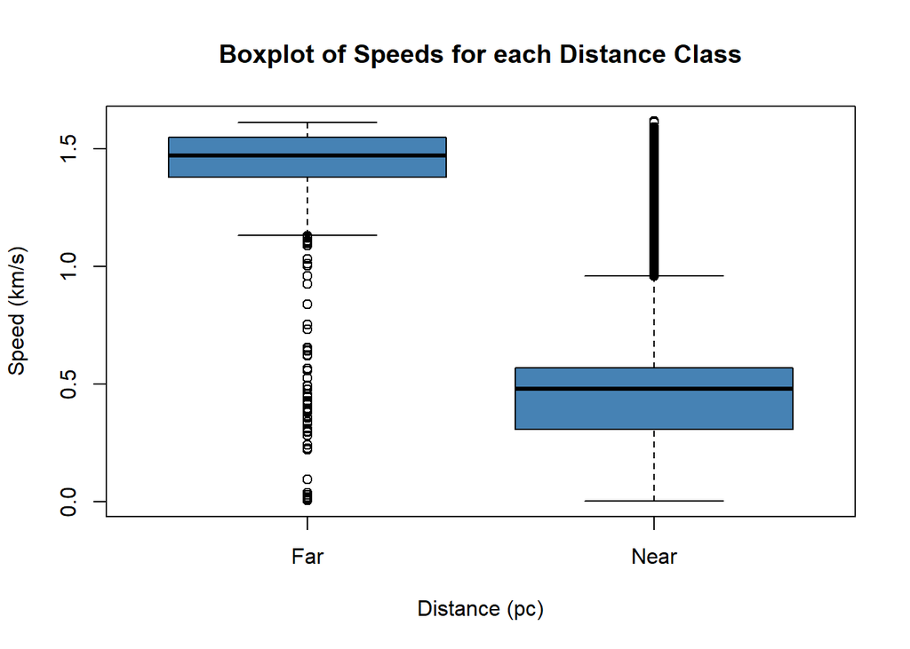

```r
boxplot(data$speed ~ data$distance_class,
        col='steelblue',
        main='Boxplot of Speeds for each Distance Class',
        xlab='Distance (pc)',
        ylab='Speed (km/s)')
```

Following the visualizations, we continued with the two-sample test. Given the different sample variances and unequal sample size, the most appropriate test would be the Welch $T$-Test, which accounts for unequal variances. Additionally, the large sizes of our samples allow the application of the Central Limit Theorem, and further enable the use of the Welch $T$-Test. We defined the null hypothesis as the mean speeds of *Near* astronomical objects being greater or equal to *Far* objects, and the alternate hypothesis as the mean speed of *Far* astronomical objects being greater than the mean speed of those that are *Near*.

$\bar{\mu}_{Near} = 0.437_{\frac{km}{s}}$  
$\bar{\mu}_{Far} = 1.419_{\frac{km}{s}}$

```r
t.test(data$speed[data$distance == "Far"], data$speed[data$distance == "Near"], alternative = "greater", var.equal = FALSE)
```

```
##
##  Welch Two Sample t-test
##
## data:  data$speed[data$distance == "Far"] and data$speed[data$distance == "Near"]
## t = 215.93, df = 2713.8, p-value < 0.00000000000000022
## alternative hypothesis: true difference in means is greater than 0
## 95 percent confidence interval:
##  0.9746164       Inf
## sample estimates:
## mean of x mean of y
## 1.4193719 0.4372717
```

We completed a right-tailed T-test and obtained a $P$-value of 2e-16. From this, we are able to reject the null hypothesis with relative confidence. This $P$-value signifies that the probability of a similar sample of far and near astronomical objects resulting in groups with the same, or more extreme, differences in mean speed values is extremely small. In other words, the test provides strong evidence that the mean speed of *Far* observable astronomical objects (between 17109.07 and 34218.14 parsecs) is greater than those that are *Near* ($\leq$ 17109.07 pa).

## Sensitivity Analysis

In light of our decision to arbitrarily categorize the distance variable, we wanted to assess the effect of alternate cutoff values. Analyzing a data set of this size presents statistical risks with regards to any conclusions or inferences. We will explore in these next chunks, just how much results can vary based on group splitting points.

### Step 1: Take an overall sample of the dataset

```r
# Ensure data is clean
starData.df <- subset(df, is.na(Dist) == FALSE & is.na(z.Flame) == FALSE, select = c("Dist", "z.Flame") )
# Take sample for computational speed
starData.sample.indices <- sample(nrow(starData.df), 50000)
starData.sample <- starData.df[starData.sample.indices,]
# Name columns
colnames(starData.sample) <- c("Dist", "Speed")
```

```r
# Create a function to run the t.test on different categorical splits
star.t.test <- function(df, splitDist){
  near.vector <- df$Speed[df$Dist < splitDist]
  far.vector <- df$Speed[df$Dist >= splitDist]
  cat("Near sample size: ", length(near.vector), "\n")
  cat("Far sample size: ", length(far.vector), "\n")

  tResult <- t.test(x = far.vector, y = near.vector, alternative="greater", var.equal=FALSE)
  tResult
}
```

### Step 2: Run favstats on sample Distance values

```r
library(mosaic)
starData.sample.favstats <- favstats(starData.sample$Dist)
dist.mean <- starData.sample.favstats$mean
dist.max <- starData.sample.favstats$max
dist.median <- starData.sample.favstats$median
dist.half.max <- dist.max / 2
```

### Step 3: Run t.test using different categorical splitting values

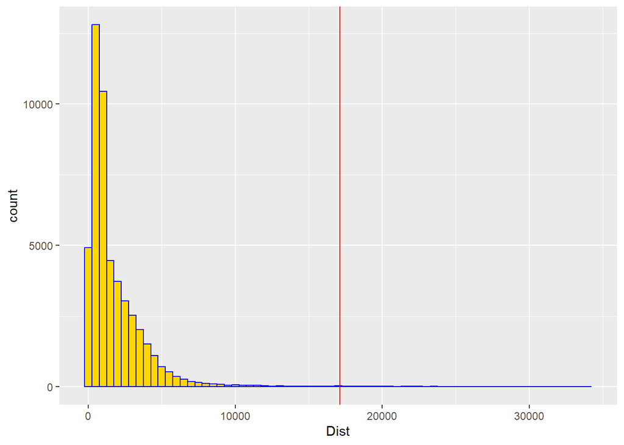

```r
ggplot(data=starData.sample, aes(x=Dist)) +
  geom_histogram(col="blue", fill="gold", binwidth=500) +
  geom_vline(xintercept=dist.half.max, col="red")
```

```r
star.t.test(starData.sample, dist.half.max)
```

```
## Near sample size:  49716
## Far sample size:  284
```

```
##
##  Welch Two Sample t-test
##
## data:  far.vector and near.vector
## t = 56.518, df = 285, p-value < 0.00000000000000022
## alternative hypothesis: true difference in means is greater than 0
## 95 percent confidence interval:
##  0.9174868       Inf
## sample estimates:
## mean of x mean of y
## 1.3814959 0.4364144
```

### Mean distance

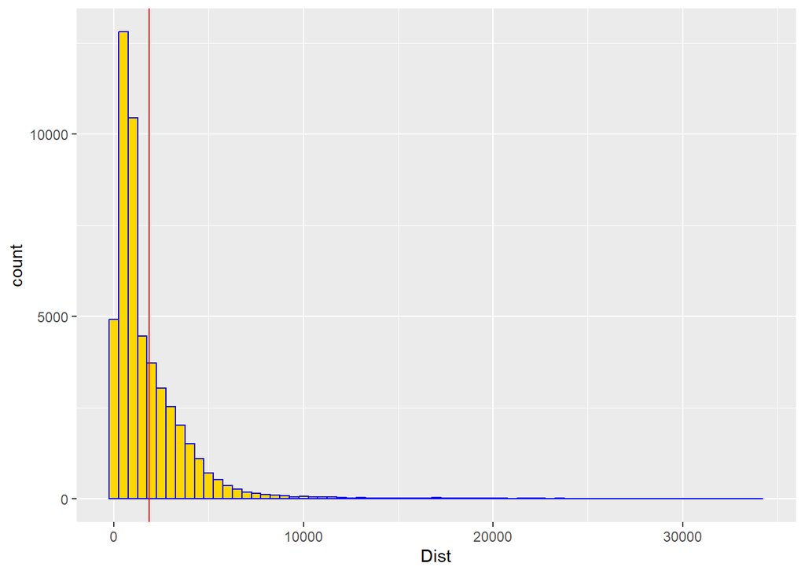

```r
ggplot(data=starData.sample, aes(x=Dist)) +
  geom_histogram(col="blue", fill="gold", binwidth=500) +
  geom_vline(xintercept=dist.mean, col="red")
```

```r
star.t.test(starData.sample, dist.mean)
```

```
## Near sample size:  33609
## Far sample size:  16391
```

```
##
##  Welch Two Sample t-test
##
## data:  far.vector and near.vector
## t = -36.285, df = 19828, p-value = 1
## alternative hypothesis: true difference in means is greater than 0
## 95 percent confidence interval:
##  -0.103572       Inf
## sample estimates:
## mean of x mean of y
## 0.3751827 0.4742630
```

### Median distance

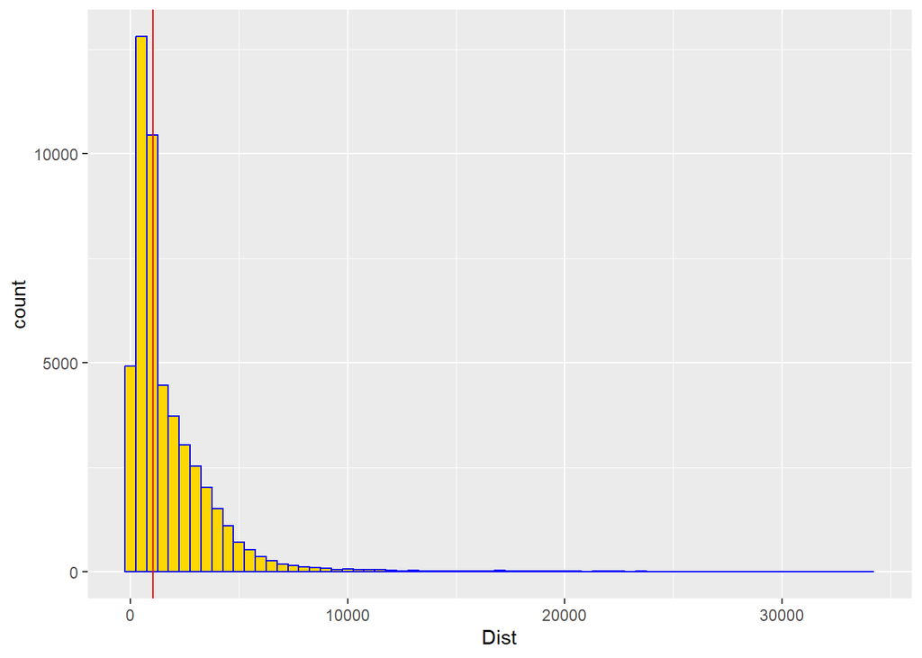

```r
ggplot(data=starData.sample, aes(x=Dist)) +
  geom_histogram(col="blue", fill="gold", binwidth=500) +
  geom_vline(xintercept=dist.median, col="red")
```

```r
star.t.test(starData.sample, dist.median)
```

```
## Near sample size:  25000
## Far sample size:  25000
```

```
##
##  Welch Two Sample t-test
##
## data:  far.vector and near.vector
## t = -65.807, df = 33932, p-value = 1
## alternative hypothesis: true difference in means is greater than 0
## 95 percent confidence interval:
##  -0.1347256        Inf
## sample estimates:
## mean of x mean of y
## 0.3760624 0.5075026
```

### 5100

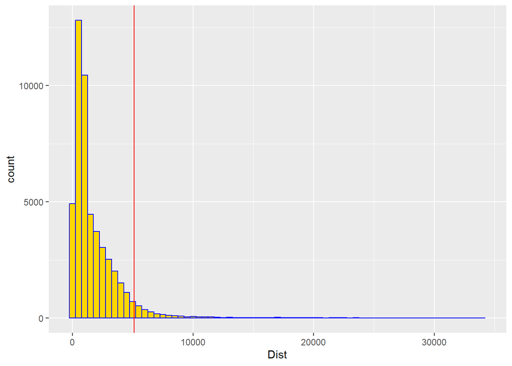

```r
ggplot(data=starData.sample, aes(x=Dist)) +
  geom_histogram(col="blue", fill="gold", binwidth=500) +
  geom_vline(xintercept=5100, col="red")
```

```r
star.t.test(starData.sample, 5100)
```

```
## Near sample size:  47093
## Far sample size:  2907
```

```
##
##  Welch Two Sample t-test
##
## data:  far.vector and near.vector
## t = 0.15494, df = 2960.2, p-value = 0.4384
## alternative hypothesis: true difference in means is greater than 0
## 95 percent confidence interval:
##  -0.01446084         Inf
## sample estimates:
## mean of x mean of y
## 0.4431984 0.4416951
```

- P-Value > 0.05, still providing strong evidence FOR $H_{0}$ *(speeds are similar for near and far)*  
- 95% confidence interval includes 0

### 5300

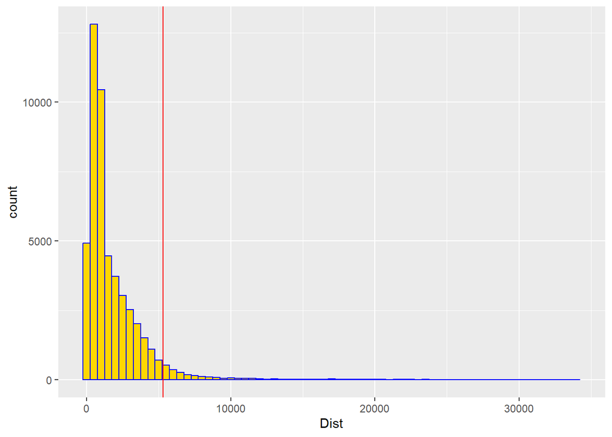

```r
ggplot(data=starData.sample, aes(x=Dist)) +
  geom_histogram(col="blue", fill="gold", binwidth=500) +
  geom_vline(xintercept=5300, col="red")
```

```r
star.t.test(starData.sample, 5300)
```

```
## Near sample size:  47345
## Far sample size:  2655
```

```
##
##  Welch Two Sample t-test
##
## data:  far.vector and near.vector
## t = 1.4304, df = 2696.7, p-value = 0.07636
## alternative hypothesis: true difference in means is greater than 0
## 95 percent confidence interval:
##  -0.00224649         Inf
## sample estimates:
## mean of x mean of y
## 0.4559339 0.4409889
```

## Comments

We observe significant statistical differences based on difference data-splitting decisions. These results highlight the general issues involved in statistical analysis and the drawing of inferences.

### Simplify the data into distance buckets

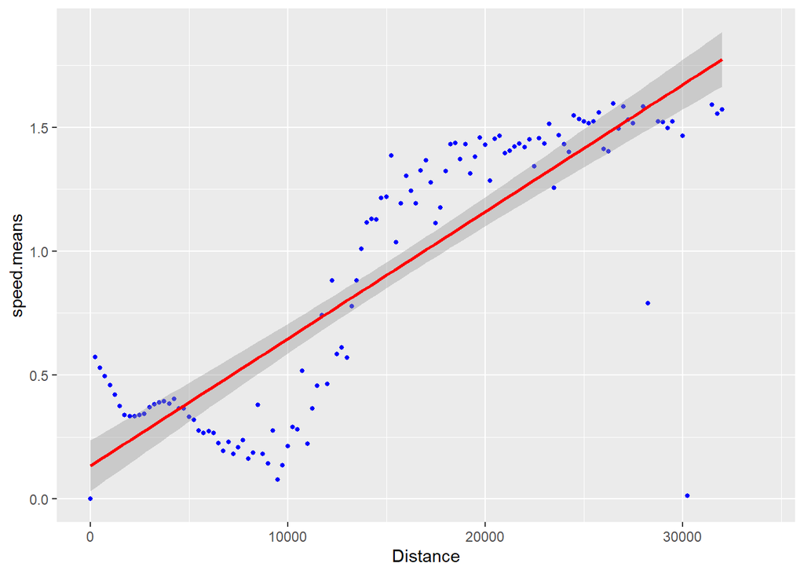

```r
break.values <- seq(0,dist.max, 250)
speed.means <- numeric(length(break.values))
lowerBound <- 0
for(i in 2:length(break.values)){
  grouped.stars <- subset(starData.sample, Dist > lowerBound & Dist <= break.values[i])
  speed.means[i] <- mean(grouped.stars$Speed)
  lowerBound <- break.values[i]
}

relation <- data.frame(break.values, speed.means)

ggplot(relation, aes(x = break.values, y=speed.means)) +
  geom_point(size=1, col="blue") +
  geom_smooth(method="lm", col="red") +
  xlab("Distance")
```

```r
# run t.test on summarized data
t.test(break.values, speed.means, alternative="greater", var.equal=FALSE)
```

```
##
##  Welch Two Sample t-test
##
## data:  break.values and speed.means
## t = 20.051, df = 136, p-value < 0.00000000000000022
## alternative hypothesis: true difference in means is greater than 0
## 95 percent confidence interval:
##  15595.03      Inf
## sample estimates:
##     mean of x     mean of y
## 17000.0000000     0.9130582
```

- P-Value < 0.05, now indicating evidence AGAINST $H_{0}$ *(speeds are similar for near and far)*  
- 95% confidence interval EXCLUDES 0, indicating significant evidence of difference

By grouping the stars into buckets and analyzing speed as a mean of stars within a distance range, we can remove a potentially biased weighting of the number of stars at different distances.

## Interpretation

Based on our results, we can make the following inferences - We can reject the Null Hypothesis (no difference between near and far speeds)  
- we can infer that observable astronomical objects that are *Far* (between 17109.07 and 34218.14 parsecs) appear to have a greater mean speed than those that are *Near* ($\leq$ 17109.07 pa).  
- This result is consistent with the generally accepted theory of how the universe is expanding as discussed in the introduction.

# Analysis 2

## Introduction

Our analysis is to determine the independence between the effective temperature and the absolute G-magnitude of the star. The effective heat of a star is the estimated effective temperature of the celestial object by Gaia in Kelvins. The absolute G-magnitude of the star is the absolute magnitude of the G-band. The G-band is a specific range of wavelengths that is found between 330 and 1050 nanometers. The magnitude scale in astronomy is a logarithmic scale used to measure the brightness of celestial objects, including stars.  
As you move up the magnitude scale, the brightness of the object decreases. The scale is such that a difference of 5 magnitudes corresponds to a factor of 100 in brightness. Therefore, a star with a magnitude of 1 is 100 times brighter than a star with a magnitude of 6. (Palacios, 2016)(Britannica, 2023)

Given this scale,

A star of the first magnitude is 2.5 times brighter than a star of the second magnitude.

A star of the second magnitude is 2.5 times brighter than a star of the third magnitude.

From the perspective of an observer on Earth, the brightest star has a G-magnitude of -1.4. Canopus, the second brightest, has a magnitude of -0.7, while the faintest star normally seen without the aid of a telescope is of the sixth magnitude. Stars as faint as the 30th magnitude have been measured with modern telescopes, meaning that these instruments can detect stars about four billion times fainter than the human eye alone. As such, it should be understood that the brightness of the star using the absolute G-magnitude of the star is highest while the magnitude is negative. Inversely, the brightness of a star is the dimmest as the magnitude increases. (Palacios, 2016)(Britannica, 2023)

It is fair to mention that there are various aspects of stellar physics and astronomy, including the study of stars’ inner parts and their continuous emission of information into space. Stars interact with other cosmic objects through gravity and radiation, and their surface conditions are determined by parameters like effective temperature and gravity. Stars’ atmospheres adjust to allow radiant heat flow, influencing their observable states. The text also touches on spectral criteria, the connection between mass and radius affecting heat outflow, and the concept of opacity hindering radiant heat transmission. Modern telescopes can detect extremely faint celestial objects, enabling the exploration of distant phenomena. (Palacios, 2016)(Britannica, 2023)

## Data Visualization

The data visualize section was primarily utilized as an exploratory data analysis (EDA) to understand the many features of our large dataset. To perform the EDA, a series of histograms and box plots were generated to understand the distribution of our features of interest.

Upon closer examination of the histograms, it was clear that the GMAG distribution mostly looked symmetrical besides the small peak to the right. It appears that it potentially may pass a normality test with a tail that might diverge at either the bottom or the top of a QQ plot. The effective temperature histogram exhibits a skewed right distribution. There are also multiple peaks, so we can say it’s multimodal.

The last visualization was used to understand the relationship between the G-band magnitude and the effective temperature. What it demonstrated was a significant amount of spread in the G-Band for stars in and around 5000 Kelvins with a decaying level of absolute G-magnitude as the effective temperature increases.

The hypothesis test will explore the independence between the effective temperature and the G-band Magnitude. As such, our hypothesis test will be structured as follows:

H_0 = Effective Temperature and G-band Magnitude are independent of each other

H_A = Effective Temperature and G-band Magnitude are not independent of each other

```r
# Import the data
starData = read.csv("C:/Users/hurdg/OneDrive/Documents/MDSA/DATA 602/Data 602 - Project/dataGaia2.csv")

# Extract the GMAG and effective temperature data
df_GMAGTeff  = data.frame(GMAG = starData$GMAG, Teff = starData$Teff)

# Provide an overview of the dataset
summary(df_GMAGTeff)
```

```
##       GMAG              Teff
##  Min.   :-7.9617   Min.   : 3039
##  1st Qu.: 0.3404   1st Qu.: 5217
##  Median : 1.9793   Median : 5958
##  Mean   : 2.2329   Mean   : 7295
##  3rd Qu.: 3.9196   3rd Qu.: 8392
##  Max.   : 9.9630   Max.   :41504
```

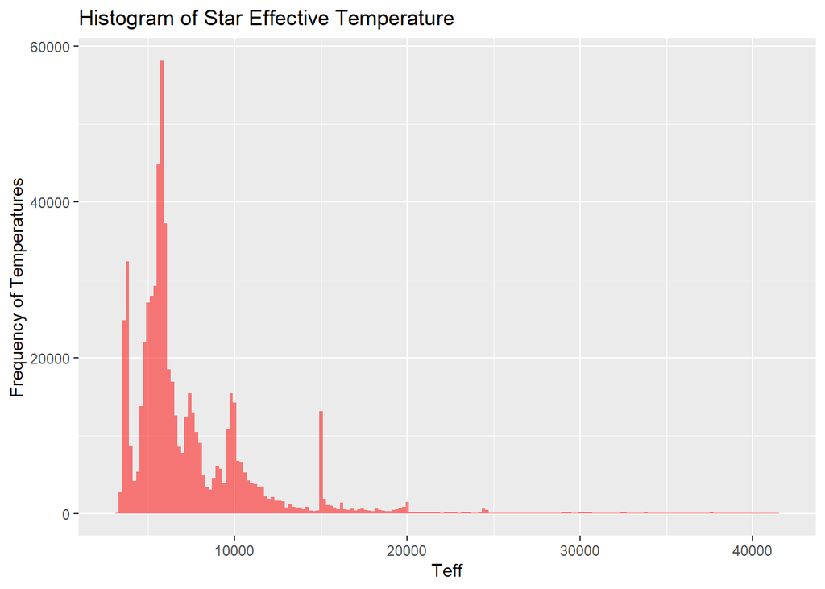

```r
# Remove NaN's from the data set
df_GMAGTeff = na.omit(df_GMAGTeff)

# Visualize a histogram of the effective temperature data
ggplot(df_GMAGTeff) +
  geom_histogram(aes(x = Teff), binwidth = 200, alpha = 0.5, fill = "red") +
  labs(title = "Histogram of Star Effective Temperature",
       y = "Frequency of Temperatures")
```

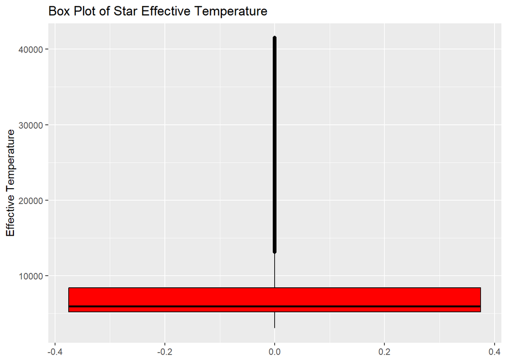

```r
# Visualize a histogram of the box plot effective temperature data
ggplot(df_GMAGTeff, aes(y = Teff)) +
  geom_boxplot(fill = "red", color = "black") +
  labs(title = "Box Plot of Star Effective Temperature",
       y = "Effective Temperature")
```

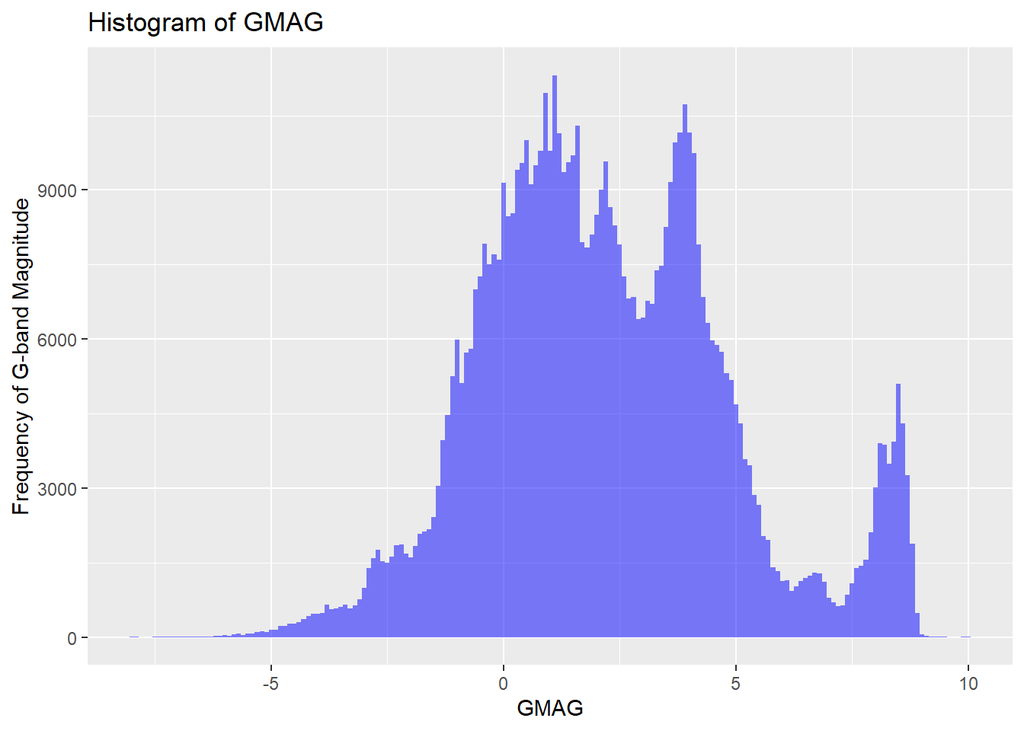

```r
# Visualize a histogram of the GMAG data
ggplot(df_GMAGTeff) +
  geom_histogram(aes(x = GMAG), binwidth = 0.1, alpha = 0.5, fill = "blue") +
  labs(title = "Histogram of GMAG",
       y = "Frequency of G-band Magnitude")
```

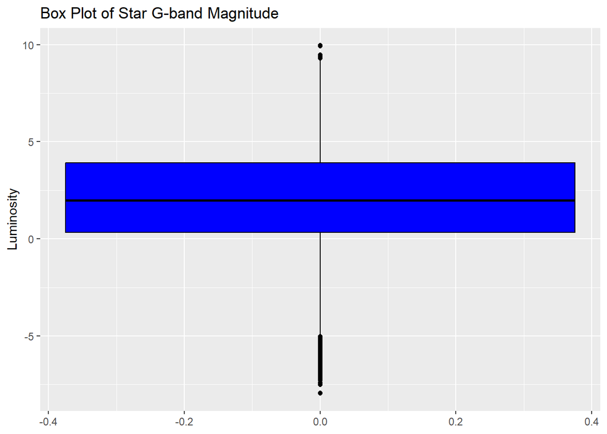

```r
# Visualize a histogram of the box plot GMAG data
ggplot(df_GMAGTeff, aes(y = GMAG)) +
  geom_boxplot(fill = "blue", color = "black") +
  labs(title = "Box Plot of Star G-band Magnitude",
       y = "Luminosity")
```

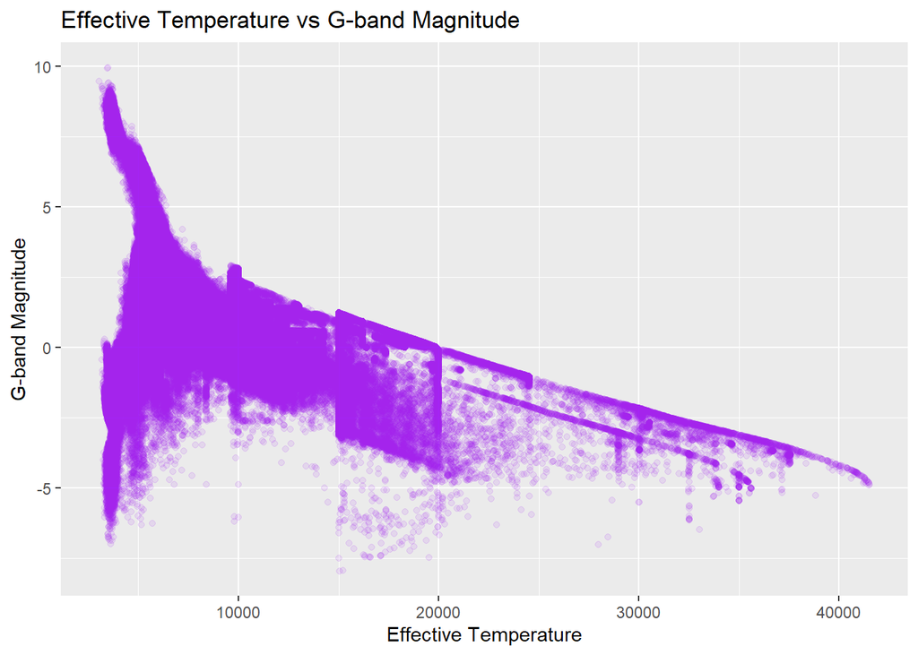

```r
# Effective temperature and GMAG
ggplot(df_GMAGTeff, aes(x = Teff, y = GMAG)) +
  geom_point(color="purple", alpha = 0.1) +
  labs(title = "Effective Temperature vs G-band Magnitude",
       y = "G-band Magnitude",
       x = "Effective Temperature")
```